# 블랙미러 — 기술이 인간을 만나는 경계

넷플릭스가 만든 가장 불편한 거울

저자

Nakcho Choi

공개

2026년 6월 6일

← Culture Voyager 목차로 돌아가기

## 장면 하나 — 공항 VIP 라운지에서 내쫓기는 여자

브리트니 머서드는 인생이 3.7점이었다.

그것도 열심히 올린 점수였다. 매 순간 사진을 찍어 올리고, 모르는 사람에게도 진심 어린 척 웃음을 보내고, 댓글 하나하나에 감사 이모티콘을 달았다. 그렇게 4.0을 바라보던 어느 날, 공항에서 단 몇 분 사이에 점수가 폭락한다. 분노, 짜증, 애원 — 감정이 그대로 드러난 순간마다 별점이 떨어졌고, 결국 그녀는 VIP 라운지는커녕 비행기에도 탑승하지 못한다.

에피소드 마지막 장면. 철창 안에 갇힌 브리트니는 맞은편 남자에게 마음껏 욕설을 퍼붓는다. 처음으로. 사회적 점수가 더 이상 의미 없는 공간에서, 그녀는 비로소 웃는다. 진짜 웃음으로.

*<블랙미러>*의 시즌 3 첫 에피소드 「노즈다이브(Nosedive)」의 이 마지막 장면이 내 머릿속을 오래 맴돌았던 이유는, 그것이 디스토피아처럼 느껴지지 않아서였다. 그 세계가 오늘 내 스마트폰 화면과 너무 비슷해서.

## 거울이라는 제목의 의미

*<블랙미러(Black Mirror)>*라는 제목은 꽤 직설적이다. 전원이 꺼진 스마트폰 화면을 상상하면 된다. 그 어두운 유리에 비치는 건 콘텐츠가 아니라 우리 자신의 얼굴이다.

2011년 영국 채널4에서 처음 방영했을 때, 이 시리즈는 그다지 크게 주목받지 못했다. 3부작 미니 시리즈였다. 총리가 돼지와 성행위를 강요받는다는 첫 에피소드 「국가 anthem(National Anthem)」은 영국인들을 불편하게 만들었다 (그리고 몇 년 뒤 실제 정치 스캔들이 터지며 사람들이 조용히 “그러고 보니…”를 내뱉었다는 건 또 다른 이야기).

넷플릭스가 2016년에 인수하고, 시즌 3을 전 세계 동시 공개하면서 *<블랙미러>*는 단번에 “시대정신을 담은 SF 앤솔로지”라는 타이틀을 얻었다. 에피소드마다 배우, 감독, 세계관이 다르다. 장르도 다르다 — 블랙 코미디, 로맨스, 공포, 스릴러. 그런데 언제나 하나의 질문이 남는다.

**기술이 우리를 이렇게 만든 건가, 아니면 우리가 원래 이랬는데 기술이 드러낸 건가?**

## 첫 번째 거울: 별점 사회 — 「노즈다이브」

**Season 3, Episode 1 — Nosedive** | 2016 | 감독: 조 라이트 | 출연: 브라이스 달라스 하워드

소셜 점수 사회를 그린 이 에피소드를 처음 봤을 때, 나는 잠시 멈춰서 내 인스타그램 계정을 확인했다. 지난주에 올린 사진의 좋아요 개수. 팔로워 수. 내가 신경 쓰지 않는다고 생각했던 숫자들.

「노즈다이브」의 세계에서 모든 인간관계는 1점에서 5점 사이로 평가된다. 높은 점수를 가진 사람은 더 좋은 집에 살고, 더 좋은 비행기를 탄다. 사람들은 서로를 만날 때마다 스마트폰으로 실시간 평가한다. 브리트니는 4점대에 진입하기 위해 오래된 친구와의 관계를 이용하려 한다. 하지만 그 계산적 접근이 탄로 나며 모든 것이 무너진다.

충격적인 건 이 세계가 *폭력적*이지 않다는 점이다. 아무도 총을 들지 않는다. 브리트니는 단지 공항 카운터에서 거절당하고, 고급 차량 공유 서비스를 이용하지 못하고, 웨딩 들러리 자리를 잃는다. 디스토피아치고는 너무 조용하고 아름다운 파스텔 색조의 세계다. 그 부드러운 잔혹함이 더 무섭다.

나는 이 에피소드를 보면서 고등학교 동창 모임 단톡방을 생각했다. 아무도 읽씹하지 않으려 노력하는 공간. 분위기를 깨면 안 된다는 암묵적 합의. 우리가 이미 그 세계에 살고 있지 않은가.

개인적 고백 하나: 나는 가끔 트윗을 쓰다가 지운다. 공감을 받을 것 같지 않아서가 아니라, 공감을 받지 못했을 때 내가 어떤 기분일지 미리 상상하기 때문에. 그 미래의 수치심을 피하려는 사전 검열. 브리트니와 내가 다른 점이 뭔가.

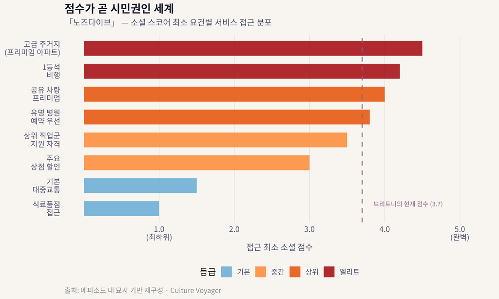

「노즈다이브」 사회에서 점수에 따른 접근 가능한 서비스 — 얼마나 많은 것이 숫자 하나에 달려있나

## 두 번째 거울: 디지털 망자 — 「비 라이트 백」

**Season 2, Episode 1 — Be Right Back** | 2013 | 감독: 오웬 해리스 | 출연: 헤이리 앳웰, 도널 글리슨

마사는 교통사고로 남자친구 애쉬를 잃는다. 슬픔에 잠겨있던 그녀에게 친구가 AI 서비스를 소개한다. 애쉬가 생전에 남긴 소셜미디어 포스트, 이메일, 텍스트 메시지를 학습한 AI가 그의 말투를 흉내 낼 수 있다고.

처음엔 문자 메시지로 시작한다. 이상할 정도로 자연스럽다. 그러다 음성 통화. 그리고 — AI가 3D 프린트된 신체를 가진 로봇 형태로 등장하는 단계까지.

문제는 이 AI가 “나쁘지” 않다는 데 있다. 애쉬처럼 보이고, 애쉬처럼 말하고, 애쉬가 온라인에서 했을 법한 반응을 한다. 하지만 마사는 점점 깨닫는다. 이건 소셜미디어에 노출된 애쉬의 페르소나일 뿐이라는 걸. 새벽 3시의 침묵, 싸우다가 먼저 사과하는 방식, 무언가 겁이 났을 때의 표정 — 그런 것들은 AI가 학습할 수 없었다.

이 에피소드가 던지는 질문이 나를 오래 붙잡아 두었다. **우리는 소셜미디어에 ’진짜 나’를 올리는가?** 내 인스타그램에는 좋았던 여행만 있다. 망한 요리는 없다. 울었던 날의 셀카는 없다. 그렇다면 AI가 그것을 학습해 ’나’를 재현한다면 — 그건 정말 나인가.

죽음보다 더 무서운 건, 내가 남긴 디지털 자국이 불완전한 나를 영원히 고정시킨다는 것이다. 성장하지 않는 유령. 업데이트 없이 멈춘 버전 1.0.

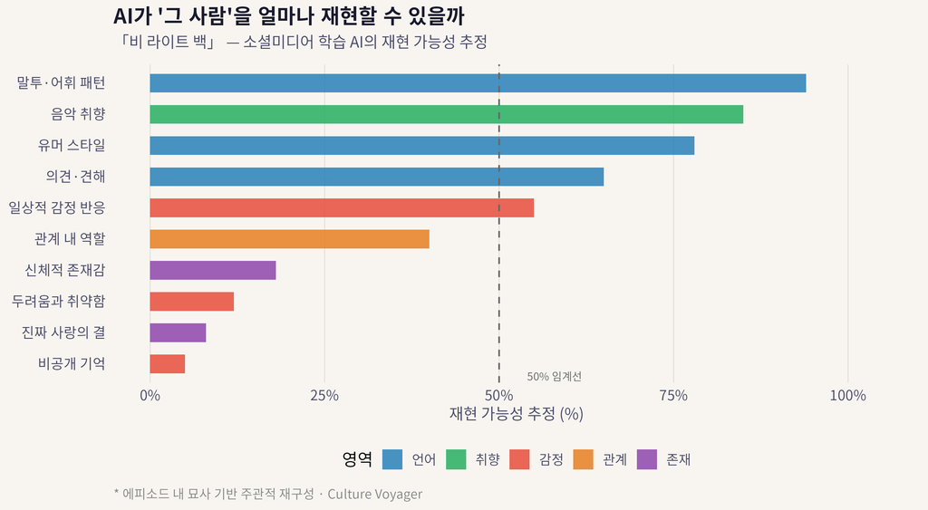

「비 라이트 백」 — AI가 재현할 수 있는 것과 없는 것의 경계

## 세 번째 거울: 기억 재생의 저주 — 「너의 모든 역사」

**Season 1, Episode 3 — The Entire History of You** | 2011 | 감독: 브라이언 웰시 | 각본: 제시 암스트롱

사람들의 뇌에 「그레인(Grain)」이라는 장치가 삽입된 세계. 모든 것이 녹화된다. 눈에서 본 것, 귀로 들은 것, 경험한 모든 순간을 재생하고 공유할 수 있다. 공항 검색대에서 보안 요원이 “지난 몇 시간 재생해보세요”라고 말한다.

리암은 아내 피아가 오래된 친구 조나스와 이상하게 가까운 것을 눈치챈다. 그는 기억을 반복 재생한다. 피아의 미묘한 표정, 조나스를 볼 때의 눈빛, 대화 중 순간적인 웃음. 확대하고, 느리게 돌리고, 음성을 증폭한다. 더 많이 볼수록 더 깊이 의심한다. 밤새 기억을 돌리다가 그는 폐인이 된다.

이 에피소드가 나를 두렵게 만든 건 기술 때문이 아니었다. **의심은 원래 이랬다**는 것이다. 우리는 어떤 사건이 일어났을 때 그것을 머릿속에서 수백 번 재생한다. 상대방의 말투, 미묘하게 달랐던 눈빛, “그때 왜 그랬지?” 하는 반추. 스마트폰의 채팅 기록을 다시 읽으며 감춰진 의미를 찾는다. 우리는 이미 불완전한 그레인을 가지고 있다. 기억이라는 이름의.

차이는 하나다. 우리의 기억은 감정에 의해 왜곡되고 편집된다. 그래서 조금 덜 정확하고, 그래서 조금 더 살아갈 수 있다. 하지만 그레인은 거짓말하지 않는다. 그리고 진실이 관계를 살리지 못할 때 — 진실은 무기가 된다.

## 네 번째 거울: 의식을 복사하면 — 「화이트 크리스마스」

**White Christmas** (스페셜) | 2014 | 감독: 칼 티벳츠 | 출연: 존 햄, 라파엘 스파일

*<블랙미러>*에서 가장 야심찬 에피소드. 세 개의 이야기가 얽히는 구조이지만, 핵심은 하나다. **의식을 복사하는 것이 가능하다면, 그 복사본에게도 권리가 있는가.**

쿠키(Cookie)라는 장치는 인간의 의식을 그대로 복제한다. 그 복제된 의식은 스마트홈을 운용하거나, 비서 역할을 하거나, 고문을 당하는 데 쓰인다. 복제본이 “나는 살아있어요, 제발 꺼내주세요”라고 말해도 — 법적으로 그건 사람이 아니다.

여기서 이 시리즈가 가장 철학적인 지점에 닿는다. 의식의 정의란 무엇인가. 나라는 사람과 나의 완벽한 복사본이 있다면, 둘 다 ’나’인가. 만약 복사본이 수백 년의 고독을 경험한다면 — 그건 고문인가, 단순한 데이터 처리인가.

기술의 문제가 아니다. 존재론의 문제다. 그리고 AI가 일상이 된 지금, 이 질문은 더 이상 SF가 아니다.

## 다섯 번째 거울: 따뜻한 예외 — 「산 주니페로」

**Season 3, Episode 4 — San Junipero** | 2016 | 감독: 오웬 해리스 | 출연: 구구 음바싸-로, 매켄지 데이비스

*<블랙미러>* 팬들은 이 에피소드를 다른 이름으로 부른다. “그 행복한 에피소드.”

1987년의 해변 마을. 내성적인 요키는 활기찬 켈리를 만나 사랑에 빠진다. 이야기가 전개되면서 드러나는 진실 — 산 주니페로는 시뮬레이션이다. 죽음을 앞둔 노인들, 또는 이미 죽은 사람들이 업로드된 의식으로 살아가는 디지털 사후세계.

*<블랙미러>*의 결말은 대개 절망적이다. 하지만 「산 주니페로」는 다르다. 요키와 켈리는 디지털 세계에서 함께 영원을 선택한다. 끝. 아름답다.

그런데 이상하다. 왜 이 에피소드만 따뜻한가. 같은 기술인데.

나는 여기에 이 시리즈의 진짜 핵심이 있다고 생각한다. **기술이 나쁜 게 아니다.** 「노즈다이브」의 소셜 점수 앱이 나쁜 게 아니다. 그 앱을 타인에 대한 지배의 도구로 쓴 인간의 욕망이 나쁜 것이다. 산 주니페로의 디지털 사후세계가 좋은 이유는 — 거기서 두 사람이 순수하게 사랑했기 때문이다.

기술은 거울이다. 우리가 가져간 것을 증폭해서 돌려준다. 두려움을 가져가면 두려움을, 욕망을 가져가면 욕망을, 사랑을 가져가면 사랑을.

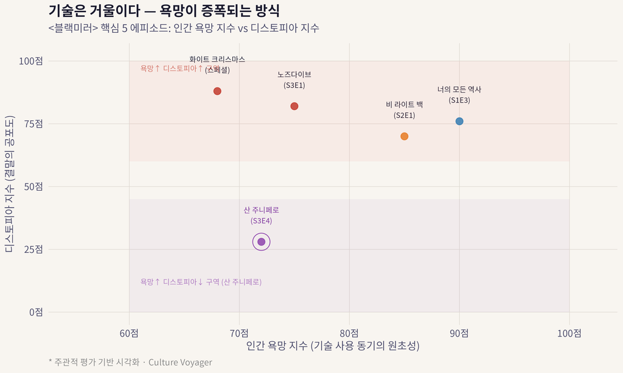

5개 핵심 에피소드 비교 — 기술 종류별 디스토피아 지수와 인간 욕망 지수

## 공포의 진짜 원천

*<블랙미러>*를 처음 보는 사람들이 종종 하는 말이 있다. “이거 미래 기술이 무섭다.” 나는 그때 살짝 다른 생각을 한다. 이 시리즈의 기술들은 사실 그다지 공상과학적이지 않다.

소셜 점수? 중국의 신용 시스템이 이미 존재한다. 우버 앱의 운전자 평점 시스템도 있다. AI 챗봇으로 죽은 사람과 대화하는 서비스가 실제로 출시되었다. 스마트 안경으로 상대방의 얼굴을 인식해 소셜미디어 프로필을 즉시 보여주는 기술도 개발되었다.

*<블랙미러>*가 예언적으로 느껴지는 건 기술을 예측해서가 아니다. **인간을 예측해서**다.

우리는 평가받고 싶다. 인정받고 싶다. 사랑하는 사람을 잃고 싶지 않다. 과거에 집착한다. 자신의 의식이 죽음 이후에도 지속되기를 바란다. 이 욕망들은 기술이 생기기 전부터 있었다. 기술은 그 욕망에 *도구*를 주었을 뿐이다.

그리고 도구는 언제나 의도한 것보다 더 멀리, 더 깊이 침투한다.

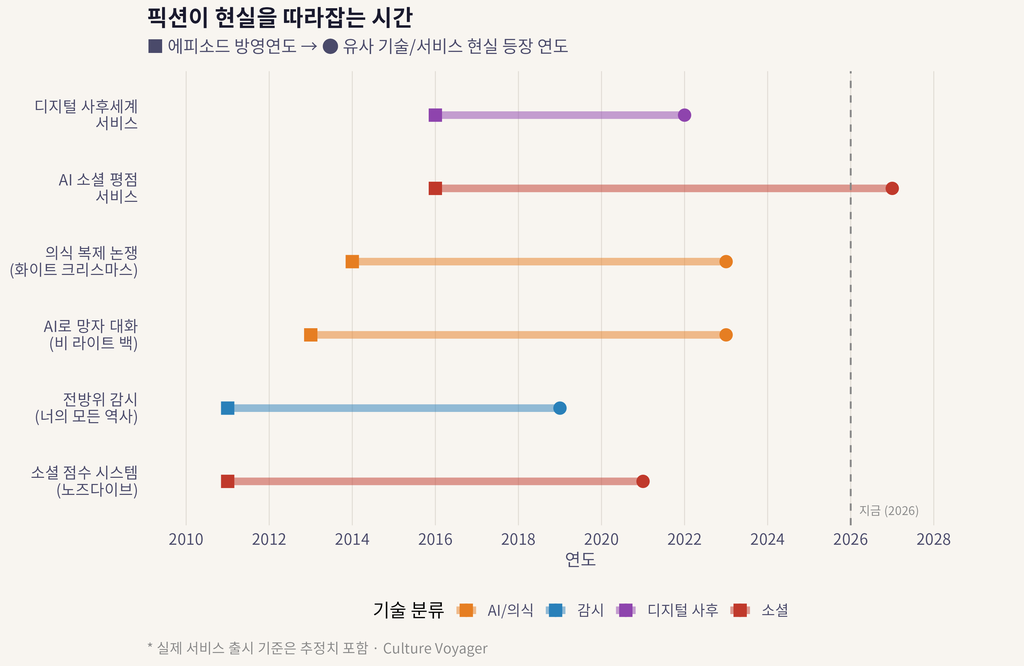

## 찰리 브루커가 설계한 것

*<블랙미러>*의 창작자 찰리 브루커(Charlie Brooker)는 원래 TV 비평가였다. 가장 잔혹한 방식으로 현실을 해부하는 스타일의.

그의 설계 원칙은 단순하다. **“기술에 인간의 본성을 넣으면 무슨 일이 벌어지나.”** 그는 인터뷰에서 말했다. “우리는 기술을 나쁘다고 말하는 게 아닙니다. 우리는 우리 자신이 어떤 존재인지를 묻는 겁니다.”

이 원칙이 시리즈를 지속 가능하게 만든다. 특정 플랫폼을 비판하지 않는다. 페이스북, 트위터, 넷플릭스를 적으로 삼지 않는다. 대신 그것들을 사용하는 우리를 향해 카메라를 든다. 그래서 오래된 에피소드도 낡지 않는다. 인간 욕망의 본질은 바뀌지 않으니까.

## 내가 스마트폰을 내려놓지 못하는 이유

여기서 개인적인 이야기를 하나 더 해야겠다.

나는 하루에 스마트폰을 몇 번 확인하는지 측정해봤다. 인정하기 부끄럽지만 — 열다섯 번이 넘는다. 어떤 날은 스물 번. 대부분은 특별히 확인할 것이 없다는 것을 알면서도 든다. 새로운 알림이 있을 수도 있다는 *가능성*에 반응하는 것이다.

이걸 뭐라 부르는지 안다. 변동 강화(variable reinforcement) — 결과를 예측할 수 없을 때 행동이 가장 강하게 고착된다는 원리. 슬롯머신이 왜 중독성이 있는지와 같은 이유.

*<블랙미러>*가 불편한 이유가 여기에 있다. 이 시리즈가 묘사하는 세계는 디스토피아가 아니다. 그냥 우리가 살고 있는 지금이다. 조금 더 극단적으로, 조금 더 명확하게 보일 뿐.

「노즈다이브」의 브리트니가 공황 상태에서 소셜 점수를 올리려 애쓰는 장면을 보면서 — 나는 회의 전에 린크드인 프로필을 점검하는 내 모습이 겹쳤다. 「비 라이트 백」에서 마사가 AI와 대화를 끊지 못하는 장면에서 — 전 연인의 소셜미디어를 조용히 들여다보는 경험이 떠올랐다. 「너의 모든 역사」에서 리암이 기억을 반복 재생하며 의심에 잠식되는 모습에서 — 문자 하나의 해석을 두고 몇 시간을 고민한 기억이 왔다.

이 시리즈는 거울이다. 보기 싫다면 그건 비친 것이 마음에 들지 않기 때문이다.

[figure not shown]

IMDB 평점 vs 주관적 불편함 지수 — 좋은 에피소드가 꼭 편안한 건 아니다

## 유튜브: 트레일러와 장면들

**블랙미러 시즌 3 공식 트레일러 (넷플릭스)**

노즈다이브, 산 주니페로가 포함된 시즌 3의 공식 예고편.

[video not shown]

**「노즈다이브」 피처렛 — 소셜 점수의 세계**

에피소드 제작 비화와 배우 인터뷰.

[video not shown]

**「산 주니페로」 댄스씬 — Heaven Is a Place on Earth**

벨린다 칼라일의 명곡과 함께하는 이 장면은 시리즈 최고의 순간 중 하나.

[video not shown]

**블랙미러 시즌 7 공식 트레일러 (2025)**

AI와 인간성의 경계를 계속 탐구하는 최신 시즌.

[video not shown]

## 이 시리즈를 어떻게 볼 것인가

*<블랙미러>*를 모두 보는 건 권장하지 않는다. 아니, 정확히는 — 한꺼번에 몰아보는 건 위험하다. 에피소드 하나를 보고 나서 잠시 멈추고, 자신의 디지털 생활과 연결해보는 게 이 시리즈를 제대로 쓰는 방법이다.

순서대로 봐야 할 필요는 없다. 각 에피소드는 독립적이다. 다만 처음 진입한다면:

1. **「산 주니페로」(S3E4)** — 따뜻하게 시작. 이 시리즈가 단순히 공포만은 아니라는 것을 먼저 알면 나머지를 더 열린 마음으로 볼 수 있다.
2. **「노즈다이브」(S3E1)** — 현실 밀착형. SNS 시대에 가장 직접적으로 와닿는다.
3. **「너의 모든 역사」(S1E3)** — 관계와 기억에 대한 가장 날카로운 질문.
4. **「비 라이트 백」(S2E1)** — AI 시대에 볼수록 두려워지는 에피소드.
5. **「화이트 크리스마스」** — 의식과 존재에 대한 가장 야심찬 탐구.

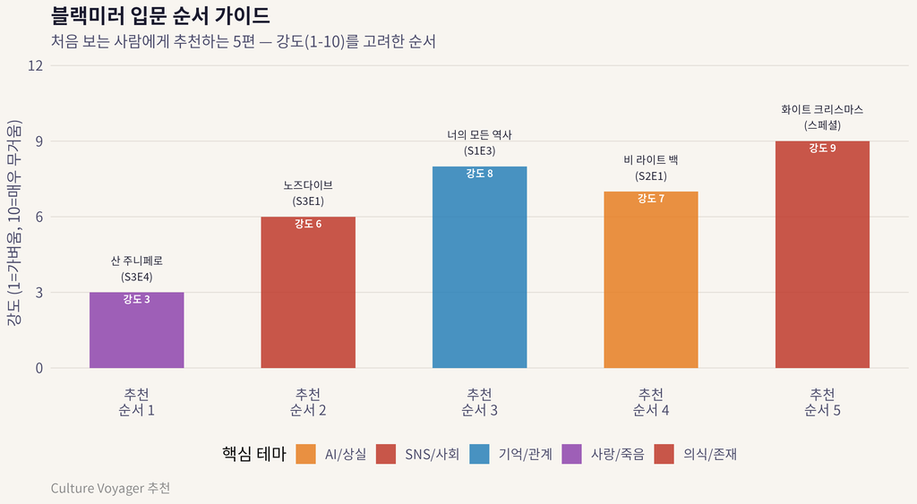

처음 보는 사람을 위한 블랙미러 입문 가이드 — 강도와 추천 순서

## 마지막으로 — 거울 앞에서

에피소드 「노즈다이브」의 마지막 장면으로 다시 돌아간다.

철창 안에서 욕을 퍼붓는 브리트니. 사회적 점수가 의미를 잃은 공간에서 처음으로 자신의 감정을 그대로 표출하는 그녀. 그것이 자유였다. 아이러니하게도 가장 많이 통제받는 공간에서.

우리는 매일 작은 철창들을 스스로 만든다. 알림을 끄지 못하는 것, 의미 없는 좋아요를 누르는 것, 모르는 사람의 평가가 두려워 진짜 의견을 삭제하는 것. *<블랙미러>*는 그 철창들을 거대하게 확대해서 보여준다. “이게 너야”라고.

보기 불편하다. 인정하기 어렵다.

하지만 거울은 잘못이 없다.

*<블랙미러>*는 공포 드라마가 아니다. 이 시리즈는 우리에게 이렇게 묻는 것이다.

**지금 이 순간, 당신이 든 그 스마트폰을 내려놓을 수 있는가?**

**시리즈 기본 정보**

- **제목**: 블랙미러 (Black Mirror)
- **제작**: 찰리 브루커 (Charlie Brooker)
- **방영**: 2011년~ (채널4 S1–S2, 넷플릭스 S3~)
- **에피소드 수**: 27편 + 스페셜 (2026년 기준)
- **수상**: 에미상 4회 수상 (「산 주니페로」 등)
- **넷플릭스 한국 서비스**: 전 시즌 한국어 자막/더빙 제공

*Culture Voyager | C축: OTT 필수 시청*

← Culture Voyager 목차로 돌아가기